# Experiment analysis step 1: populations and canonical datasets

Participant flow, attrition/compliance, and analysis-ready exports

W241 Plank Study

2026-04-12

## 0.1 Purpose

This document creates the first set of experiment-analysis objects:

1. `analysis/derived/participant_flow.csv`
2. `analysis/derived/paired_analysis.csv`
3. `analysis/derived/long_repeated_measures.csv`

It uses:

- `w241_experiment_wide.csv` for observed sessions, condition-level outcomes, and survey/process variables.
- `W241 Plank Study Data - participants.csv` for the full registered participant roster.

## 0.2 Load inputs

```r
participants <- read_participants()
wide <- read_experiment_wide()

stopifnot(uniqueN(participants$participant_id) == nrow(participants))
stopifnot(uniqueN(wide$participant_id) == nrow(wide))
stopifnot(all(wide$participant_id %in% participants$participant_id))

participants[, assigned_order := fcase(
  group_label == "trancepop", "high_tempo_first",
  group_label == "poptrance", "low_tempo_first",
  default = NA_character_
)]
```

## 0.3 Reading the flow correctly

This step intentionally starts from the **full initial distribution** and only then narrows to the analytic samples.

- First, we show the full registered roster and how many participants reach each observation stage.
- Next, we separate **attrition** (for example, not returning for session 2) from **compliance / protocol exclusions**.
- Only after those counts are visible do we define the **primary analytic sample** and the **first-period benchmark sample**.

This mirrors the report plan: the reader should see the whole study population first, then exactly why some participants are not used for a given estimand.

## 0.4 Build participant flow dataset

The participant roster is the base denominator for flow accounting. We left-join the experiment wide file onto the full participant list so registered participants with zero observed sessions still appear in the flow dataset.

```r
flow <- merge(
  participants,
  wide,
  by = "participant_id",
  all.x = TRUE,
  suffixes = c("_participant", "")
)

flow[, registered := 1L]
flow[, randomized := as.integer(!is.na(assigned_order))]
flow[, order_observed := as.integer(!is.na(crossover_order))]
flow[, period1_observed := as.integer(!is.na(plank_s1))]
flow[, period2_observed := as.integer(!is.na(plank_s2))]
flow[, completed_both_observed := as.integer(!is.na(plank_s1) & !is.na(plank_s2))]
flow[, attrited_before_session2 := as.integer(period1_observed == 1L & period2_observed == 0L)]

flow[, missing_primary_condition := as.integer(is.na(plank_high_tempo) | is.na(plank_low_tempo))]
flow[, impossible_time := as.integer(
  (!is.na(plank_high_tempo) & plank_high_tempo > 600) |
    (!is.na(plank_low_tempo) & plank_low_tempo > 600)
)]
flow[, washout_violation := as.integer(
  completed_both_observed == 1L &
    !is.na(elapsed_sessions_hours) &
    elapsed_sessions_hours < 24
)]

flow[, in_primary_analysis := as.integer(
  completed_both_observed == 1L &
    missing_primary_condition == 0L &
    impossible_time == 0L &
    washout_violation == 0L
)]

flow[, in_first_period_benchmark := as.integer(
  randomized == 1L &
    period1_observed == 1L &
    !is.na(plank_s1) &
    plank_s1 <= 600
)]

flow[, primary_exclusion_reason := fcase(
  in_primary_analysis == 1L, NA_character_,
  missing_primary_condition == 1L, "missing one condition",
  impossible_time == 1L, "impossible time > 600s",
  washout_violation == 1L, "washout < 24h",
  default = "other"
)]

flow[, benchmark_exclusion_reason := fcase(
  in_first_period_benchmark == 1L, NA_character_,
  randomized == 0L, "not randomized",
  period1_observed == 0L, "missing session 1 outcome",
  !is.na(plank_s1) & plank_s1 > 600, "impossible session 1 time > 600s",
  default = "other"
)]

setorder(flow, participant_registered_at, participant_id)
```

## 0.5 Participant flow summaries

```r
flow_table <- data.table(
  population = c(
    "Registered participants",
    "Randomized order assigned",
    "Session 1 observed",
    "Session 2 observed",
    "Completed both sessions",
    "Primary analytic sample",
    "First-period benchmark sample"
  ),
  n = c(
    nrow(flow),
    flow[, sum(randomized)],
    flow[, sum(period1_observed)],
    flow[, sum(period2_observed)],
    flow[, sum(completed_both_observed)],
    flow[, sum(in_primary_analysis)],
    flow[, sum(in_first_period_benchmark)]
  )
)

kable(flow_table, caption = "Table A. Participant flow")
```

Table A. Participant flow

| population | n |
| --- | --- |
| Registered participants | 58 |
| Randomized order assigned | 58 |
| Session 1 observed | 47 |
| Session 2 observed | 40 |
| Completed both sessions | 40 |
| Primary analytic sample | 38 |
| First-period benchmark sample | 46 |

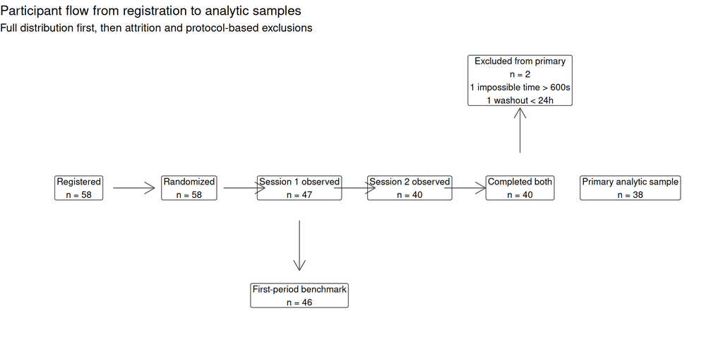

```r
flow_nodes <- data.table(
  id = c("registered", "randomized", "session1", "session2", "completed", "primary", "benchmark", "excluded"),
  x = c(1.2, 3.6, 6.0, 8.4, 10.8, 13.2, 6.0, 10.8),
  y = c(3.1, 3.1, 3.1, 3.1, 3.1, 3.1, 0.95, 5.25),
  label = c(
    paste0("Registered\nn = ", nrow(flow)),
    paste0("Randomized\nn = ", flow[, sum(randomized)]),
    paste0("Session 1 observed\nn = ", flow[, sum(period1_observed)]),
    paste0("Session 2 observed\nn = ", flow[, sum(period2_observed)]),
    paste0("Completed both\nn = ", flow[, sum(completed_both_observed)]),
    paste0("Primary analytic sample\nn = ", flow[, sum(in_primary_analysis)]),
    paste0("First-period benchmark\nn = ", flow[, sum(in_first_period_benchmark)]),
    paste0(
      "Excluded from primary\nn = ", flow[, sum(completed_both_observed)] - flow[, sum(in_primary_analysis)],
      "\n1 impossible time > 600s\n1 washout < 24h"
    )
  )
)

flow_edges <- data.table(
  x = c(1.95, 4.35, 6.75, 9.15, 6.0, 10.8),
  y = c(3.1, 3.1, 3.1, 3.1, 2.45, 3.8),
  xend = c(2.85, 5.25, 7.65, 10.05, 6.0, 10.8),
  yend = c(3.1, 3.1, 3.1, 3.1, 1.45, 4.7)
)

ggplot() +
  geom_segment(
    data = flow_edges,
    aes(x = x, y = y, xend = xend, yend = yend),
    arrow = grid::arrow(length = grid::unit(0.18, "inches")),
    linewidth = 0.45,
    color = "gray35"
  ) +
  geom_label(
    data = flow_nodes,
    aes(x = x, y = y, label = label),
    label.size = 0.25,
    size = 3.5,
    label.padding = grid::unit(0.18, "lines")
  ) +
  coord_cartesian(xlim = c(0.2, 14.5), ylim = c(0.3, 5.9), clip = "off") +
  labs(
    title = "Participant flow from registration to analytic samples",
    subtitle = "Full distribution first, then attrition and protocol-based exclusions"
  ) +
  theme_void(base_size = 12)
```

```r
attrition_by_order <- flow[
  randomized == 1L,
  .(
    started_session1 = sum(period1_observed),
    dropped_before_session2 = sum(attrited_before_session2),
    retained_completed_both = sum(completed_both_observed)
  ),
  by = assigned_order
][order(assigned_order)]

kable(attrition_by_order, caption = "Table B. Attrition by randomized order")
```

Table B. Attrition by randomized order

| assigned_order | started_session1 | dropped_before_session2 | retained_completed_both |
| --- | --- | --- | --- |
| high_tempo_first | 23 | 4 | 19 |
| low_tempo_first | 24 | 3 | 21 |

```r
compliance_table <- data.table(
  issue = c(
    "Impossible time > 600s",
    "Washout violation < 24h",
    "Missing one condition",
    "Excluded from primary analysis"
  ),
  n = c(
    flow[, sum(impossible_time)],
    flow[, sum(washout_violation)],
    flow[, sum(missing_primary_condition)],
    flow[, sum(in_primary_analysis == 0L & completed_both_observed == 1L)]
  )
)

kable(compliance_table, caption = "Table C. Compliance and exclusion reasons")
```

Table C. Compliance and exclusion reasons

| issue | n |
| --- | --- |
| Impossible time > 600s | 1 |
| Washout violation < 24h | 1 |
| Missing one condition | 18 |
| Excluded from primary analysis | 2 |

## 0.6 Build paired analytic dataset

The paired dataset keeps one row per primary analytic participant and standardizes condition-level secondary outcomes so later Rmds can work in `high_tempo` / `low_tempo` terms directly.

```r
paired <- flow[
  in_primary_analysis == 1L,
  .(
    participant_id,
    crossover_order,
    first_session_is_high_tempo,
    participant_age,
    participant_gender,
    participant_locale,
    participant_group_index,
    participant_group_label,
    participant_registered_at,
    participant_session1_planned_at,
    participant_session2_planned_at,
    elapsed_sessions_hours,
    first_period_condition = audio_s1,
    second_period_condition = audio_s2,
    first_period_tte = plank_s1,
    second_period_tte = plank_s2,
    high_tempo_tte = plank_high_tempo,
    low_tempo_tte = plank_low_tempo,
    diff_high_minus_low,
    energy_high_tempo = condition_from_sessions(audio_s1, audio_s2, pre_energy_pre_plank_s1, pre_energy_pre_plank_s2, "high_tempo"),
    energy_low_tempo = condition_from_sessions(audio_s1, audio_s2, pre_energy_pre_plank_s1, pre_energy_pre_plank_s2, "low_tempo"),
    motivation_high_tempo = condition_from_sessions(audio_s1, audio_s2, pre_motivation_pre_plank_s1, pre_motivation_pre_plank_s2, "high_tempo"),
    motivation_low_tempo = condition_from_sessions(audio_s1, audio_s2, pre_motivation_pre_plank_s1, pre_motivation_pre_plank_s2, "low_tempo"),
    music_liking_high_tempo = condition_from_sessions(audio_s1, audio_s2, pre_music_liking_s1, pre_music_liking_s2, "high_tempo"),
    music_liking_low_tempo = condition_from_sessions(audio_s1, audio_s2, pre_music_liking_s1, pre_music_liking_s2, "low_tempo"),
    rpe_high_tempo = condition_from_sessions(audio_s1, audio_s2, post_rpe_s1, post_rpe_s2, "high_tempo"),
    rpe_low_tempo = condition_from_sessions(audio_s1, audio_s2, post_rpe_s1, post_rpe_s2, "low_tempo"),
    headphones_high_tempo = condition_from_sessions(audio_s1, audio_s2, post_headphones_s1, post_headphones_s2, "high_tempo"),
    headphones_low_tempo = condition_from_sessions(audio_s1, audio_s2, post_headphones_s1, post_headphones_s2, "low_tempo"),
    pause_high_tempo = condition_from_sessions(audio_s1, audio_s2, post_plank_pause_s1, post_plank_pause_s2, "high_tempo"),
    pause_low_tempo = condition_from_sessions(audio_s1, audio_s2, post_plank_pause_s1, post_plank_pause_s2, "low_tempo"),
    volume_clear_high_tempo = condition_from_sessions(audio_s1, audio_s2, post_volume_clear_s1, post_volume_clear_s2, "high_tempo"),
    volume_clear_low_tempo = condition_from_sessions(audio_s1, audio_s2, post_volume_clear_s1, post_volume_clear_s2, "low_tempo"),
    activity_level_baseline = pre_activity_level_s1,
    activity_type_baseline = pre_activity_type_s1,
    plank_frequency_baseline = pre_plank_frequency_s1
  )
]

stopifnot(uniqueN(paired$participant_id) == nrow(paired))
```

## 0.7 Build long repeated-measures dataset

The long dataset keeps one row per observed session and carries analysis flags so later model files can subset consistently without re-implementing the exclusion logic.

```r
make_period_dt <- function(base, sn) {
  audio_col <- paste0("audio_s", sn)
  plank_col <- paste0("plank_s", sn)
  out <- data.table(
    participant_id = base$participant_id,
    period = sn,
    treatment = base[[audio_col]],
    high_tempo = as.integer(base[[audio_col]] == "high_tempo"),
    crossover_order = base$crossover_order,
    first_session_is_high_tempo = base$first_session_is_high_tempo,
    outcome_tte = base[[plank_col]],
    pre_energy = base[[paste0("pre_energy_pre_plank_s", sn)]],
    pre_motivation = base[[paste0("pre_motivation_pre_plank_s", sn)]],
    pre_music_liking = base[[paste0("pre_music_liking_s", sn)]],
    post_rpe = base[[paste0("post_rpe_s", sn)]],
    post_headphones = base[[paste0("post_headphones_s", sn)]],
    post_plank_pause = base[[paste0("post_plank_pause_s", sn)]],
    post_volume_clear = base[[paste0("post_volume_clear_s", sn)]],
    participant_age = base$participant_age,
    participant_gender = base$participant_gender,
    participant_locale = base$participant_locale,
    activity_level_baseline = base$pre_activity_level_s1,
    activity_type_baseline = base$pre_activity_type_s1,
    plank_frequency_baseline = base$pre_plank_frequency_s1,
    impossible_time = base$impossible_time,
    washout_violation = base$washout_violation,
    in_primary_analysis = base$in_primary_analysis,
    in_first_period_benchmark = base$in_first_period_benchmark
  )
  out[!is.na(out$treatment) & !is.na(out$outcome_tte)]
}

long_dt <- rbindlist(list(make_period_dt(flow, 1L), make_period_dt(flow, 2L)), fill = TRUE)
setorder(long_dt, participant_id, period)

stopifnot(all(long_dt$period %in% c(1L, 2L)))
```

## 0.8 Write derived outputs

```r
participant_flow <- flow[, .(
  participant_id,
  participant_age = age,
  participant_gender = gender,
  participant_locale = locale,
  participant_group_index = group_index,
  participant_group_label = group_label,
  participant_sessions_completed = sessions_completed,
  participant_registered_at = registered_at,
  participant_session1_planned_at = session1_planned_at,
  participant_session2_planned_at = session2_planned_at,
  assigned_order,
  registered,
  randomized,
  order_observed,
  period1_observed,
  period2_observed,
  completed_both_observed,
  attrited_before_session2,
  missing_primary_condition,
  impossible_time,
  washout_violation,
  in_primary_analysis,
  in_first_period_benchmark,
  primary_exclusion_reason,
  benchmark_exclusion_reason
)]

write_derived_csv(participant_flow, "participant_flow.csv")
write_derived_csv(paired, "paired_analysis.csv")
write_derived_csv(long_dt, "long_repeated_measures.csv")
```

## 0.9 Verification

```r
pf <- fread(derived_path("participant_flow.csv"))
pd <- fread(derived_path("paired_analysis.csv"))
ld <- fread(derived_path("long_repeated_measures.csv"))

stopifnot(nrow(pf) == nrow(participants))
stopifnot(all(wide$participant_id %in% pf$participant_id))
stopifnot(nrow(pd) == flow[, sum(in_primary_analysis)])
stopifnot(uniqueN(pd$participant_id) == nrow(pd))
stopifnot(nrow(ld) == flow[, sum(period1_observed + period2_observed)])

message("Wrote ", nrow(pf), " rows to ", derived_path("participant_flow.csv"))
## Wrote 58 rows to /home/user/MIDS/w241/analysis/derived/participant_flow.csv
message("Wrote ", nrow(pd), " rows to ", derived_path("paired_analysis.csv"))
## Wrote 38 rows to /home/user/MIDS/w241/analysis/derived/paired_analysis.csv
message("Wrote ", nrow(ld), " rows to ", derived_path("long_repeated_measures.csv"))
## Wrote 87 rows to /home/user/MIDS/w241/analysis/derived/long_repeated_measures.csv
```